## Course: VISUAL ANALYTICS FOR POLICY AND MANAGEMENT

### Prof. José Manuel Magallanes, PhD

- Visiting Professor of Computational Policy at Evans School of Public Policy and Governance, and eScience Institute Senior Data Science Fellow, University of Washington.
- Professor of Government and Political Methodology, Pontificia Universidad Católica del Perú.

# Session 7: Spatial Data

# Opening data files

Let’s open our data:

```r
linkCSV='https://github.com/Visual-Analytics-Project-UW-EvansSchool/mergedData/raw/main/merged_data.csv'

dataCSV=read.csv(linkCSV)
```

This is what you have:

```r
str(dataCSV)
```

```
## 'data.frame':    139 obs. of  5 variables:
##  $ ISO3      : chr  "AFG" "AGO" "ALB" "ARE" ...
##  $ Country   : chr  "Afghanistan" "Angola" "Albania" "United Arab Emirates" ...
##  $ DemoIndex : num  2.85 3.66 6.08 2.7 6.95 5.35 8.96 8.16 2.68 2.14 ...
##  $ HDI       : num  0.511 0.581 0.795 0.89 0.845 0.776 0.944 0.922 0.756 0.433 ...
##  $ mil_expend: num  1.2 1.6 1.47 5.7 0.7 4.9 1.9 0.7 4 1.8 ...
```

Now let me open the map:

```r
linkMap="https://github.com/Visual-Analytics-Project-UW-EvansSchool/ourMap/raw/main/worldMap.geojson" # link desde github
library(sf)
```

```r
mapWorld=read_sf(linkMap)
```

This is the data that came with the map:

```r
# see data in map
head(mapWorld)
```

```
## Simple feature collection with 6 features and 11 fields
## geometry type:  MULTIPOLYGON
## dimension:      XY
## bbox:           xmin: -61.88722 ymin: -18.01639 xmax: 50.37499 ymax: 42.61805
## geographic CRS: WGS 84
## # A tibble: 6 x 12
##   FIPS  ISO2  ISO3     UN NAME    AREA POP2005 REGION SUBREGION    LON   LAT
##   <chr> <chr> <chr> <int> <chr>  <int>   <int>  <int>     <int>  <dbl> <dbl>
## 1 AC    AG    ATG      28 Anti…     44  8.30e4     19        29 -61.8   17.1
## 2 AG    DZ    DZA      12 Alge… 238174  3.29e7      2        15   2.63  28.2
## 3 AJ    AZ    AZE      31 Azer…   8260  8.35e6    142       145  47.4   40.4
## 4 AL    AL    ALB       8 Alba…   2740  3.15e6    150        39  20.1   41.1
## 5 AM    AM    ARM      51 Arme…   2820  3.02e6    142       145  44.6   40.5
## 6 AO    AO    AGO      24 Ango… 124670  1.61e7      2        17  17.5  -12.3
## # … with 1 more variable: geometry <MULTIPOLYGON [°]>
```

Let’s add our data to the map data by merging:

```r
mapWorldVars=merge(mapWorld, #map first
                   dataCSV,
                   by='ISO3')
```

You can map the data now using ggplot. Let me do it by layers:

1. Base layer:

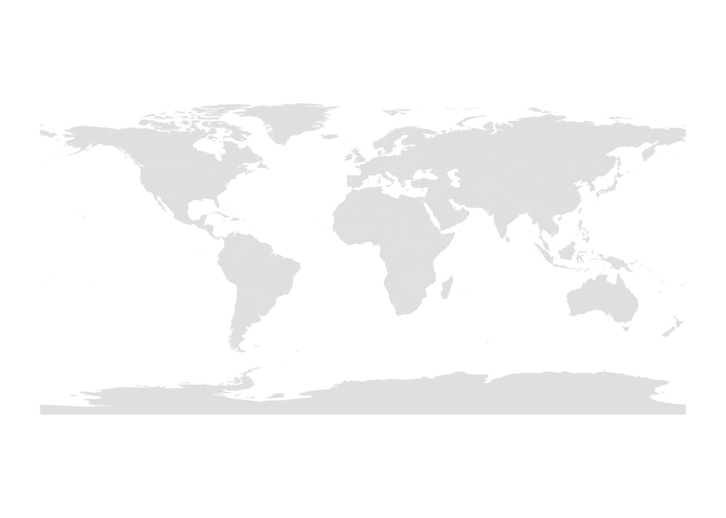

```r
library(ggplot2)
# plot original map
base=ggplot(data=mapWorld) + geom_sf(fill='grey90',
                                     color=NA) + theme_classic()

base #base map
```

2. Data layer:

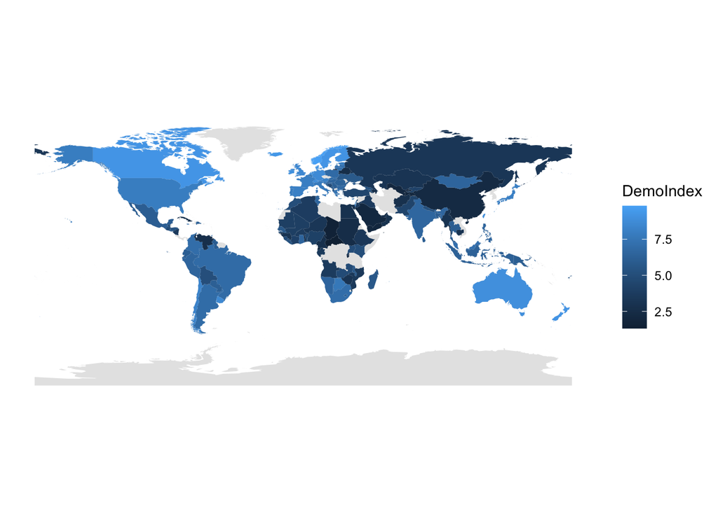

```r
colMap= base + geom_sf(data=mapWorldVars,
                       aes(fill=DemoIndex),
                       color=NA)
colMap
```

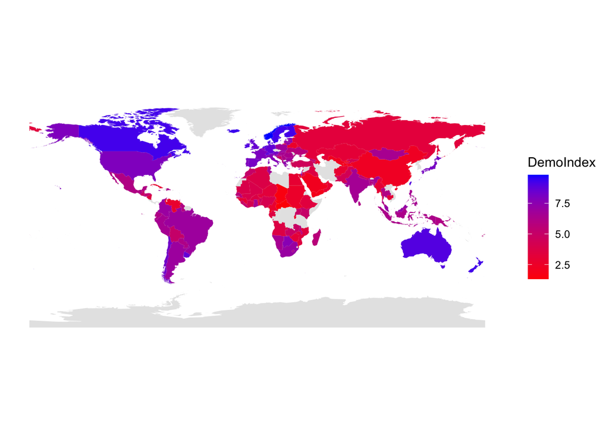

```r
colMap + scale_fill_gradient(low = 'red',
                             high= 'blue')
```

You can try creating a cluster variable: Let’s see the behavior of each variable of interest:

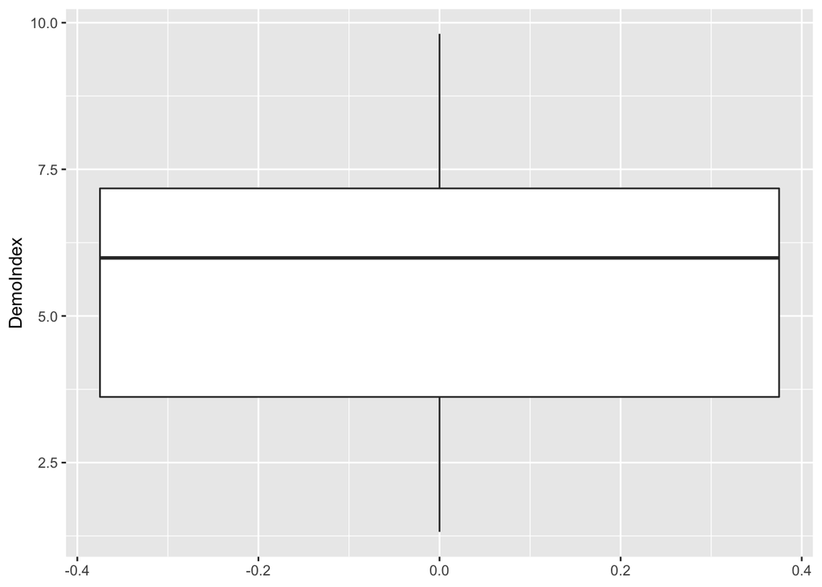

```r
ggplot(data=mapWorldVars) + geom_boxplot(aes(y=DemoIndex))
```

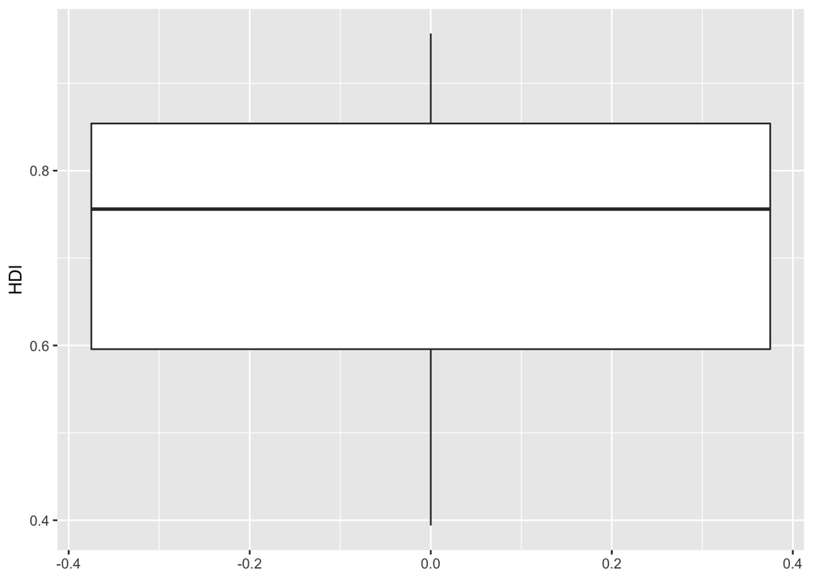

```r
ggplot(data=mapWorldVars) + geom_boxplot(aes(y=HDI))
```

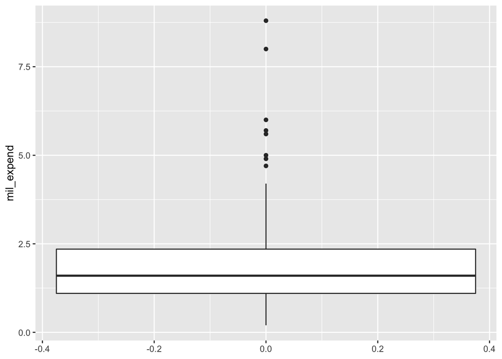

```r
ggplot(data=mapWorldVars) + geom_boxplot(aes(y=mil_expend))
```

One of the data show outliers. We can try **standardization**:

```r
mapWorldVars$HDI_S=as.vector(scale(mapWorldVars$HDI))
mapWorldVars$DEM_S=as.vector(scale(mapWorldVars$DemoIndex))
mapWorldVars$MIL_S=as.vector(scale(mapWorldVars$mil_expend))
```

Let’s get some clusters:

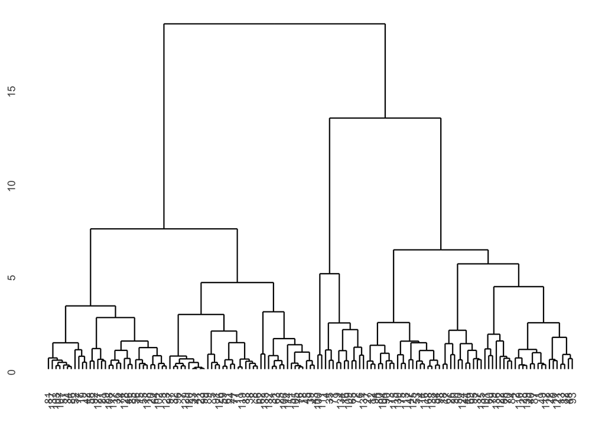

```r
#data to cluster
library(cluster)
vars=c('HDI_S','DEM_S','MIL_S')

set.seed(123)
distvars=mapWorldVars[,vars]%>%
          st_drop_geometry() %>%
             cluster::daisy()

res.hier=hclust(distvars,"ward.D2")

library(ggdendro)
ggdendrogram(res.hier)
```

Let’s get the clusters:

#### 1. Apply function: you need to indicate the amount of clusters required.

```r
numberOfClusters=5

mapWorldVars$clustH=cutree(res.hier,k=5)%>%as.factor()
```

Check order:

```r
vars2=c('HDI_S','DEM_S','MIL_S','clustH')
aggregate(.~clustH,
          data=mapWorldVars[,vars2]%>%
          st_drop_geometry(),
          FUN=median)
```

```
##   clustH      HDI_S       DEM_S      MIL_S
## 1      1 -1.0590017 -1.15865673 -0.2435426
## 2      2  0.2342360  0.34655705 -0.2435426
## 3      3  0.3170542 -1.05310820  1.9432154
## 4      4  1.2025716  1.15652727 -0.3211373
## 5      5 -1.1418198 -0.04121906 -0.5609752
```

Give the right order:

```r
mapWorldVars$clustH=factor(mapWorldVars$clustH,
                           levels=c(5,1,2,3,4),
                           labels=c(1,2,3,4,5),
                           ordered=T)
```

Now paint the countries (ggplot decides color):

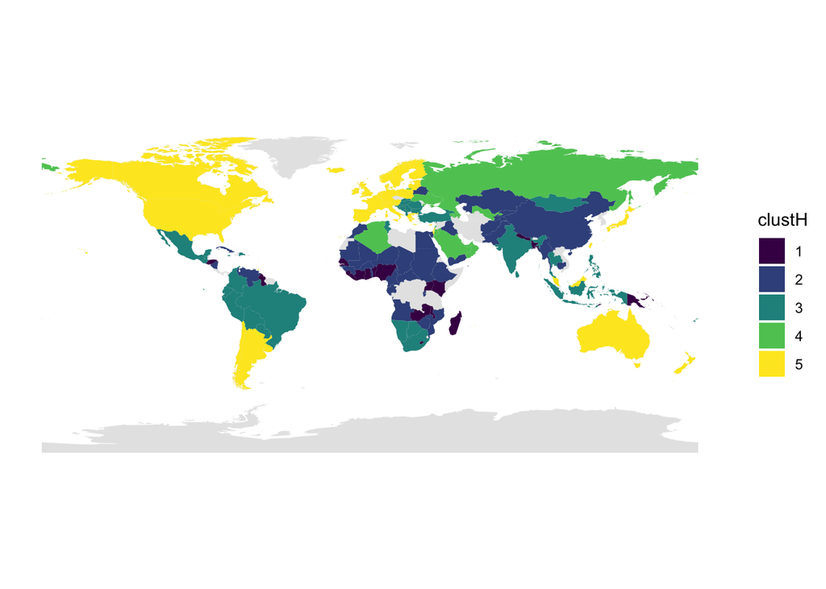

```r
clusterMap= base + geom_sf(data=mapWorldVars,
                           aes(fill=clustH),
                           color=NA) # color of border
clusterMap
```

Now you choose the palette (get it from [here](http://colorbrewer2.org/)):

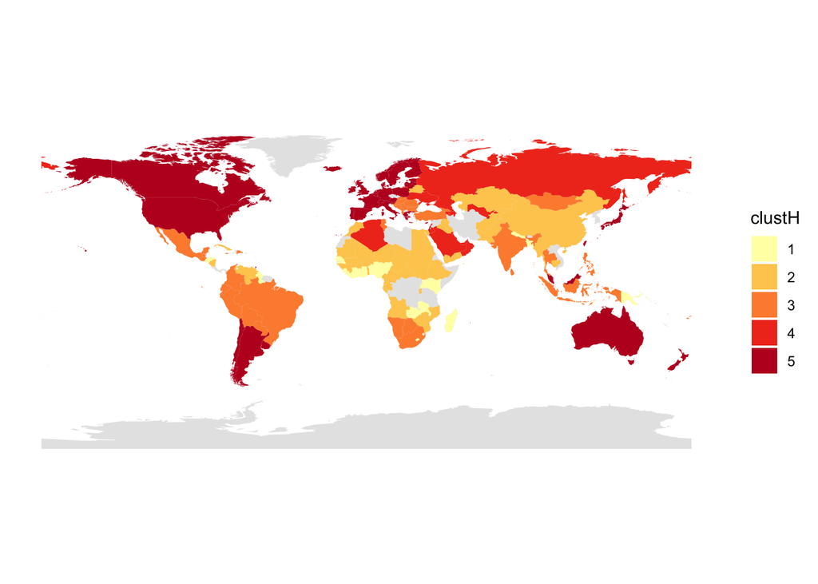

```r
clusterMap+ scale_fill_brewer(palette ='YlOrRd')
```

Some more customization:

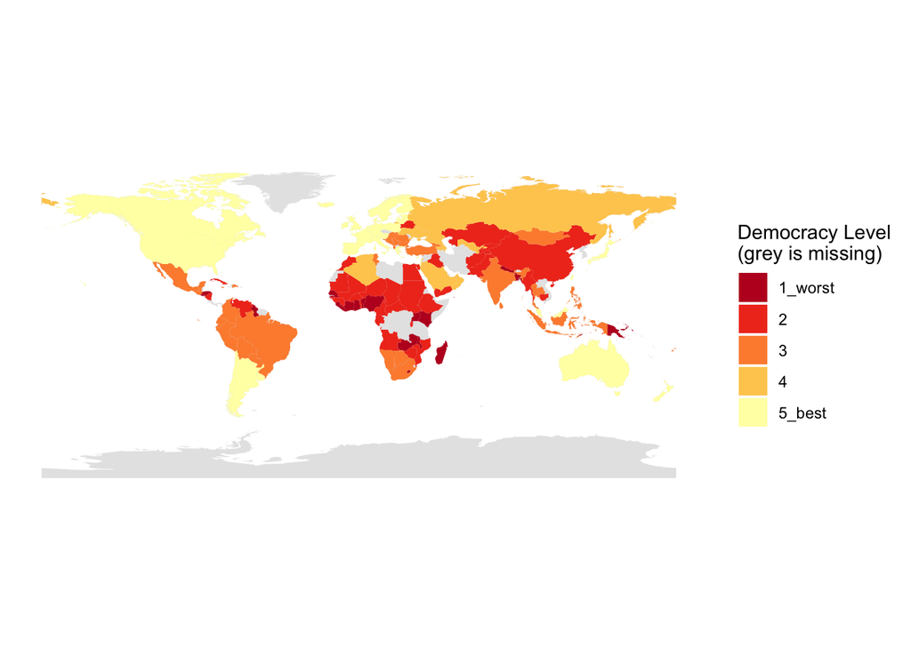

```r
#previously
theLegLabels=c('1_worst',2,3,4,'5_best')
theLegTitle="Democracy Level\n(grey is missing)"

#now
clusterMap+ scale_fill_brewer(palette ='YlOrRd',
                              direction = -1, # color order
                              labels=theLegLabels,
                              name=theLegTitle)
```

home